# Lecture 7. Bayesian Learning

**Learning in an uncertain world**

Joaquin Vanschoren

[figure not shown]

XKCD, Randall Monroe

## Bayes' rule

Rule for updating the probability of a hypothesis $c$ given data $x$

[figure not shown]

$P(c|x)$ is the posterior probability of class $c$ given data $x$.  
$P(c)$ is the *prior* probability of class $c$: what you believed before you saw the data $x$  
$P(x|c)$ is the *likelihood* of data point $x$ given that the class is $c$ (computed from your dataset)  
$P(x)$ is the prior probability of the data (*marginal likelihood*): the likelihood of the data $x$ under any circumstance (no matter what the class is)

### Example: exploding sun

- Let's compute the probability that the sun has exploded
- Prior $P(exploded)$: the sun has an estimated lifespan of 10 billion years, $P(exploded) = \frac{1}{4.38 x 10^{13}}$
- Likelihood that detector lies: $P(lie)= \frac{1}{36}$

$$ \begin{aligned} P(exploded|yes) &= \frac{P(yes|exploded)P(exploded)}{P(yes)} \\ &= \frac{(1-P(lie)) P(exploded)}{P(exploded)(1-P(lie))+P(lie)(1-P(exploded))} \\ &= \frac{1}{1.25226 x 10^{12}} \end{aligned}$$

- The one positive observation of the detector increases the probability

### Example: COVID test

- What is the probability of having COVID-19 if a 96% accurate test returns positive? Assume a false positive rate of 4%
- Prior $P(C): 0.015$ (117M cases, 7.9B people)
- $P(TP)=P(pos|C)=0.96$, and $P(FP)=(pos|notC)=0.04$
- If test is positive, prior becomes $P(C)=0.268$. 2nd positive test: $P(C|pos)=0.9$

$$ \begin{aligned} P(C|pos) &= \frac{P(pos|C)P(C)}{P(pos)} \\ &= \frac{P(pos|C) P(C)}{P(pos|C)P(C)+P(pos|notC)(1-P(C))} \\ &= \frac{0.96*0.015}{0.96*0.015+0.04*0.985} \\ &= 0.268 \end{aligned}$$

## Bayesian models

- Learn the joint distribution $P(x,y)=P(x|y)P(y)$.
  - Assumes that the data is Gaussian distributed (!)
  - With every input $x$ you get $P(y|x)$, hence a mean and standard deviation for $y$ (blue)
  - For every desired output $y$ you get $P(x|y)$, hence you can sample new points $x$ (red)
- Easily updatable with new data using Bayes' rule ('turning the crank')
  - Previous posterior $P(y|x)$ becomes new prior $P(y)$

```
interactive(children=(FloatSlider(value=0.0, description='x', max=3.0, min=-3.0, step=0.5), FloatSlider(value=…
```

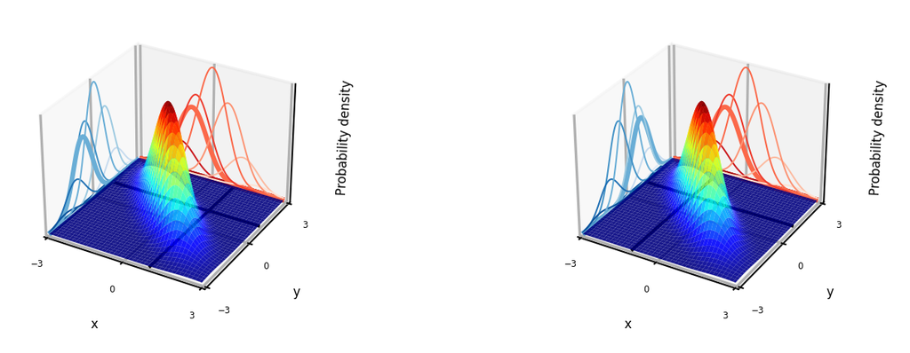

### Generative models

- The joint distribution represents the training data for a particular output (e.g. a class)
- You can sample a *new* point $\textbf{x}$ with high predicted likelihood $P(x,c)$: that new point will be very similar to the training points
- Generate new (likely) points according to the same distribution: *generative model*
  - Generate examples that are *fake* but corresponding to a desired output
  - Generative neural networks (e.g. GANs) can do this very accurately for text, images, ...

[figure not shown]

### Naive Bayes

- Predict the probability that a point belongs to a certain class, using Bayes' Theorem

$$P(c|\textbf{x}) = \frac{P(\textbf{x}|c)P(c)}{P(\textbf{x})}$$

- Problem: since $\textbf{x}$ is a vector, computing $P(\textbf{x}|c)$ can be very complex
- Naively assume that all features are conditionally independent from each other, in which case:  
  $P(\mathbf{x}|c) = P(x_1|c) \times P(x_2|c) \times ... \times P(x_n|c)$
- Very fast: only needs to extract statistics from each feature.

#### On categorical data

What's the probability that your friend will play golf if the weather is sunny?

[figure not shown]

#### On numeric data

- We need to fit a distribution (e.g. Gaussian) over the data points
- GaussianNB: Computes mean $\mu_c$ and standard deviation $\sigma_c$ of the feature values per class: $p(x=v \mid c)=\frac{1}{\sqrt{2\pi\sigma^2_c}}\,e^{ -\frac{(v-\mu_c)^2}{2\sigma^2_c} }$
- We can now make predictions using Bayes' theorem: $p(c \mid \mathbf{x}) = \frac{p(\mathbf{x} \mid c) \ p(c)}{p(\mathbf{x})}$

[figure not shown]

- What do the predictions of Gaussian Naive Bayes look like?

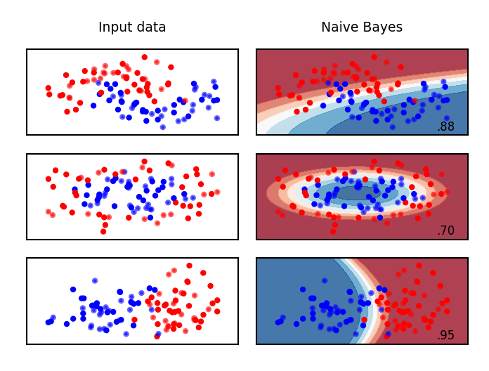

Other Naive Bayes classifiers:

- BernoulliNB
  - Assumes binary data
  - Feature statistics: Number of non-zero entries per class
- MultinomialNB
  - Assumes count data
  - Feature statistics: Average value per class
  - Mostly used for text classification (bag-of-words data)

### Bayesian Networks

- What if we know that some variables are not independent?
- A *Bayesian Network* is a directed acyclic graph representing variables as nodes and conditional dependencies as edges.
- If an edge $(A, B)$ connects random variables A and B, then $P(B|A)$ is a factor in the joint probability distribution. We must know $P(B|A)$ for all values of $B$ and $A$
- The graph structure can be designed manually or learned (hard!)

[figure not shown]

### Gaussian processes

- Model the data as a Gaussian distribution, conditioned on the training points

```
interactive(children=(IntSlider(value=10, description='nr_points', max=20), Output()), _dom_classes=('widget-i…
```

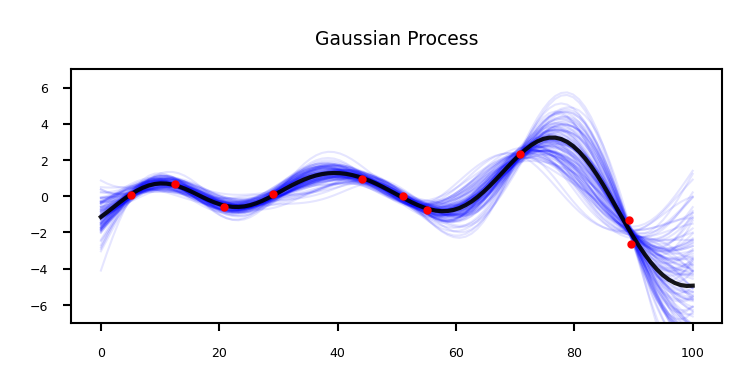

## Probabilistic interpretation of regression

Linear regression (recap):

$$y = f(\mathbf{x}_i) = \mathbf{x}_i\mathbf{w} + b $$

For one input feature: $$y = w_1 \cdot x_1 + b \cdot 1$$

We can solve this via linear algebra (closed form solution): $w^{*} = (X^{T}X)^{-1} X^T Y$

```
w = np.linalg.solve(np.dot(X.T, X), np.dot(X.T, y))
```

$\mathbf{X}$ is our data matrix with a $x_0=1$ column to represent the bias $b$:

$$\mathbf{X} = \begin{bmatrix} \mathbf{x}_1^\top \\\ \mathbf{x}_2^\top \\\ \vdots \\\ \mathbf{x}_N^\top \end{bmatrix} = \begin{bmatrix} 1 & x_1 \\\ 1 & x_2 \\\ \vdots & \vdots \\\ 1 & x_N \end{bmatrix}$$

#### Example: Olympic marathon data

We learned: $ y= w_1 x + w_0 = -0.013 x + 28.895$

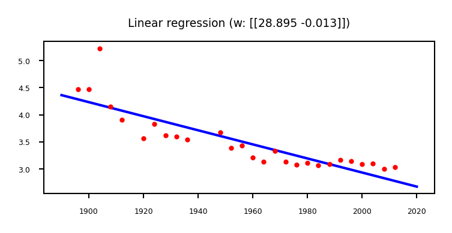

### Polynomial regression (recap)

We can fit a 2nd degree polynomial by using a basis expansion (adding more *basis functions*):

$$\mathbf{\Phi} = \left[ \mathbf{1} \quad \mathbf{x} \quad \mathbf{x}^2\right]$$

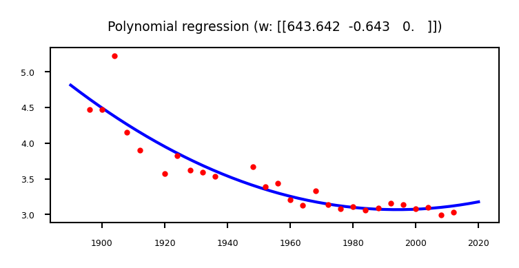

### Kernelized regression (recap)

We can also kernelize the model and learn a dual coefficient per data point

```
interactive(children=(IntSlider(value=4, description='poly_degree', max=8, min=1), IntSlider(value=-6, descrip…
```

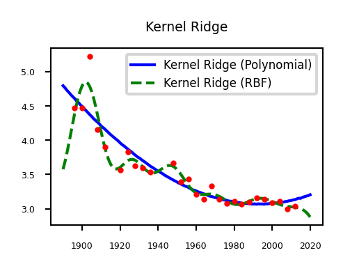

### Probabilistic interpretation

- These models do not give us any indication of the (un)certainty of the predictions
- Assume that the data is inherently uncertain. This can be modeled explictly by introducing a [slack variable](http://en.wikipedia.org/wiki/Slack_variable), $\epsilon_i$, known as noise.

$$y_i = w_1 x_i + w_0 + \epsilon_i.$$

- Assume that the noise is distributed according to a Gaussian distribution with zero mean and variance $\sigma^2$.

$$\epsilon_i \sim \mathcal{N}(0, \sigma^2)$$

- That means that $y(x)$ is now a Gaussian distribution with mean $\mathbf{wx}$ and variance $\sigma^2$

$$y = \mathcal{N}(\mathbf{wx}, \sigma^2)$$

We have an uncertainty predictions, but it is the same for all predictions

- You would expect to be more certain nearby your training points

```
interactive(children=(FloatSlider(value=0.005, description='sigma', max=0.01, min=0.001, step=0.001), Output()…
```

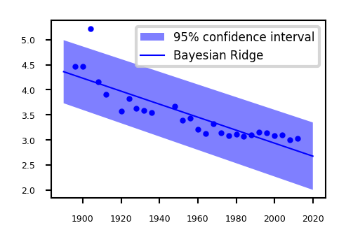

## How to learn probabilities?

- Maximum Likelihood Estimation (MLE): Maximize $P(\textbf{X}|\textbf{w})$
  - Corresponds to optimizing $\mathbf{w}$, using (log) likelihood as the loss function
  - Every prediction has a mean defined by $\textbf{w}$ and Gaussian noise $$P(\textbf{X}|\textbf{w}) = \prod_{i=0}^{n} P(\mathbf{y}_i|\mathbf{x}_i;\mathbf{w}) = \prod_{i=0}^{n} \mathcal{N}(\mathbf{wx,\sigma^2 I})$$
- Maximum A Posteriori estimation (MAP): Maximize the posterior $P(\textbf{w}|\textbf{X})$
  - This can be done using Bayes' rule after we choose a (Gaussian) prior $P(\textbf{w})$: $$P(\textbf{w}|\textbf{X}) = \frac{P(\textbf{X}|\textbf{w})P(\textbf{w})}{P(\textbf{X})}$$
- Bayesian approach: model the prediction $P(y|x_{test},X)$ directly
  - Marginalize $w$ out: consider all possible models (some are more likely)
  - If prior $P(\textbf{w})$ is Gaussian, then $P(y|x_{test},\textbf{X})$ is also Gaussian!
    - A multivariate Gaussian with mean $\mu$ and covariance matrix $\Sigma$ $$P(y|x_{test},\textbf{X}) = \int_w P(y|x_{test},\textbf{w}) P(\textbf{w}|\textbf{X}) dw = \mathcal{N}(\mathbf{\mu,\Sigma})$$

### Gaussian prior $P(w)$

In the Bayesian approach, we assume a *prior (Gaussian) distribution* for the parameters, $\mathbf{w} \sim \mathcal{N}(\mathbf{0}, \alpha \mathbf{I})$:

- With zero mean ($\mu$=0) and covariance matrix $\alpha \mathbf{I}$. For 2D: $ \alpha \mathbf{I} = \begin{bmatrix} \alpha & 0 \\ 0 & \alpha \end{bmatrix}$

I.e, $w_i$ is drawn from a Gaussian density with variance $\alpha$ $$w_i \sim \mathcal{N}(0,\alpha)$$

```
interactive(children=(FloatSlider(value=0.5, description='alpha', max=1.0, min=0.1), Checkbox(value=False, des…
```

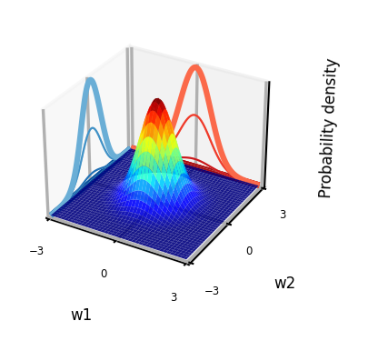

### Sampling from the prior (weight space)

We can sample from the prior distribution to see what form we are imposing on the functions *a priori* (before seeing any data).

- Draw $w$ (left) independently from a Gaussian density $\mathbf{w} \sim \mathcal{N}(\mathbf{0}, \alpha\mathbf{I})$
  - Use any normally distributed sampling technique, e.g. Box-Mueller transform
- Every sample yields a polynomial function $f(\mathbf{x})$ (right): $f(\mathbf{x}) = \mathbf{w} \boldsymbol{\phi}(\mathbf{x}).$
  - For example, with $\boldsymbol{\phi}(\mathbf{x})$ being a polynomial:

```
interactive(children=(FloatSlider(value=2.1, description='alpha', max=5.0, min=0.1, step=0.5), IntSlider(value…
```

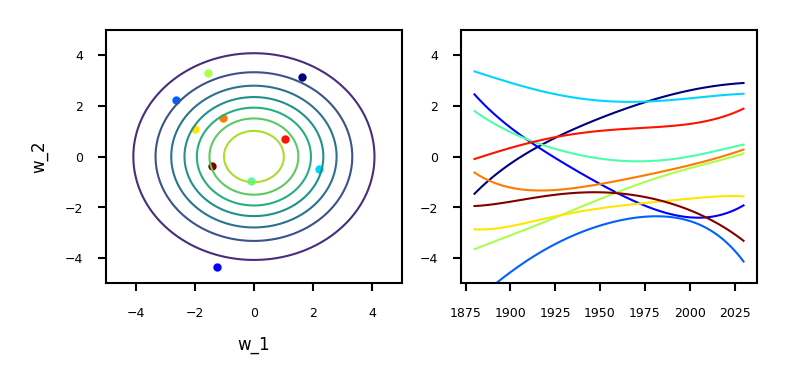

### Learning Gaussian distributions

- We assume that our data is Gaussian distributed: $P(y|x_{test},\textbf{X}) = \mathcal{N}(\mathbf{\mu,\Sigma})$
- Example with learned mean $[m,m]$ and covariance $\begin{bmatrix} \alpha & \beta \\ \beta & \alpha \end{bmatrix}$
  - The blue curve is the predicted $P(y|x_{test},\textbf{X})$

```
interactive(children=(FloatSlider(value=0.0, description='x_test', max=3.0, min=-3.0, step=0.5), FloatSlider(v…
```

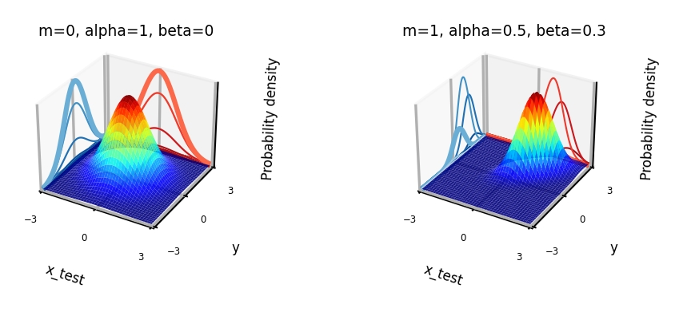

### Understanding covariances

- If two variables $x_i$ covariate strongly, knowing about $x_1$ tells us a lot about $x_2$
- If covariance is 0, knowing $x_1$ tells us nothing about $x_2$ (the conditional and marginal distributions are the same)
- For covariance matrix $\begin{bmatrix} 1 & \beta \\ \beta & 1 \end{bmatrix}$:

```
interactive(children=(FloatSlider(value=0.0, description='x1', max=3.0, min=-3.0, step=0.5), FloatSlider(value…
```

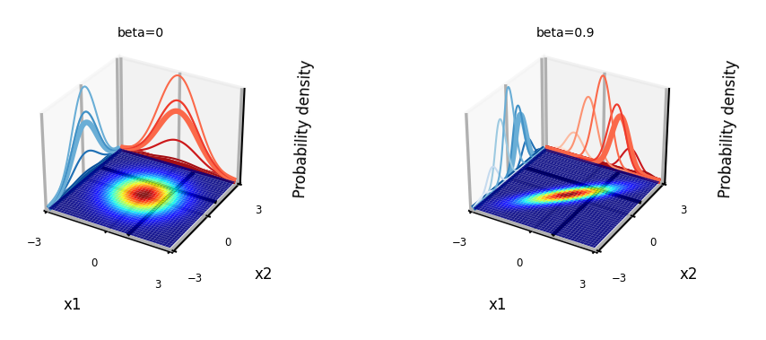

### Sampling from higher-dimensional distributions

- Instead of sampling $\mathbf{w}$ and then multiplying by $\boldsymbol{\Phi}$, we can also generate examples of $f(x)$ directly.
- $\mathbf{f}$ with $n$ values can be sampled from an $n$-dimensional Gaussian distribution with zero mean and covariance matrix $\mathbf{K} = \alpha \boldsymbol{\Phi}\boldsymbol{\Phi}^\top$:
  - $\mathbf{f}$ is a *stochastic process*: series of normally distributed variables (interpolated in the plot)

$$\mathbf{f} \sim \mathcal{N}(\mathbf{0},\mathbf{K})$$

```
interactive(children=(FloatSlider(value=1.0, description='alpha', max=2.0, min=0.1), IntSlider(value=51, descr…
```

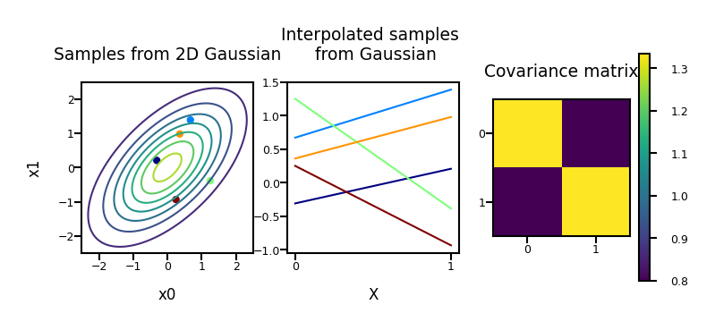

Repeat for 40 dimensions, with $\boldsymbol{\Phi}$ the polynomial transform:

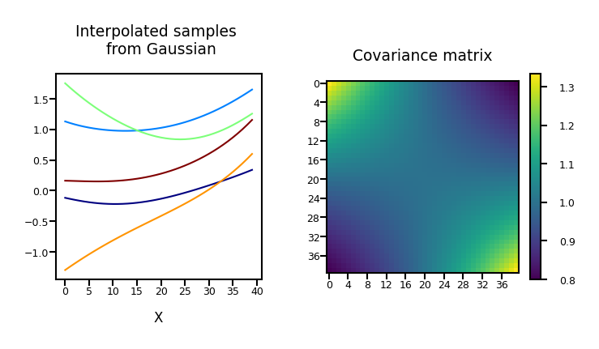

[More examples of covariances](https://pymc3-testing.readthedocs.io/en/rtd-docs/notebooks/GP-covariances.html)

#### Noisy functions

We normally add Gaussian noise to obtain our observations: $$ \mathbf{y} = \mathbf{f} + \boldsymbol{\epsilon} $$

```
interactive(children=(FloatSlider(value=0.05, description='sigma', max=0.1, min=0.01, step=0.01), Output()), _…
```

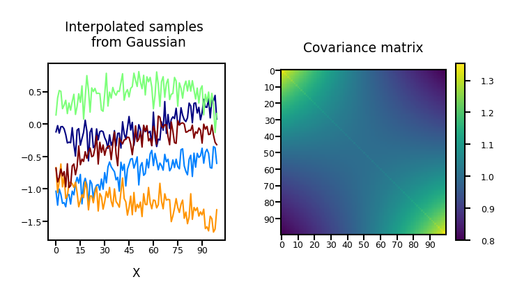

## Gaussian Process

- Usually, we want our functions to be *smooth*: if two points are similar/nearby, the predictions should be similar.
  - Hence, we need a similarity measure (a kernel)
- In a Gaussian process we can do this by specifying the *covariance function* directly (not as $\mathbf{K} = \alpha \boldsymbol{\Phi}\boldsymbol{\Phi}^\top$)
  - The covariance matrix is simply the kernel matrix: $\mathbf{f} \sim \mathcal{N}(\mathbf{0},\mathbf{K})$
- The RBF (Gaussian) covariance function (or *kernel*) is specified by

$$ k(\mathbf{x}, \mathbf{x}^\prime) = \alpha \exp\left( -\frac{\left\Vert \mathbf{x}-\mathbf{x}^\prime\right\Vert^2}{2\ell^2}\right). $$

where $\left\Vert\mathbf{x} - \mathbf{x}^\prime\right\Vert^2$ is the squared distance between the two input vectors

$$ \left\Vert\mathbf{x} - \mathbf{x}^\prime\right\Vert^2 = (\mathbf{x} - \mathbf{x}^\prime)^\top (\mathbf{x} - \mathbf{x}^\prime) $$

and the length parameter $l$ controls the smoothness of the function and $\alpha$ the vertical variation.

Now the influence of a point decreases smoothly but exponentially

- These are our priors $P(y) = \mathcal{N}(\mathbf{0,\mathbf{K}})$, with mean 0
- We now want to condition it on our training data: $P(y|x_{test},\textbf{X}) = \mathcal{N}(\mathbf{\mu,\Sigma})$

```
interactive(children=(FloatSlider(value=1.0, description='alpha', max=2.0, min=0.1), IntSlider(value=10, descr…
```

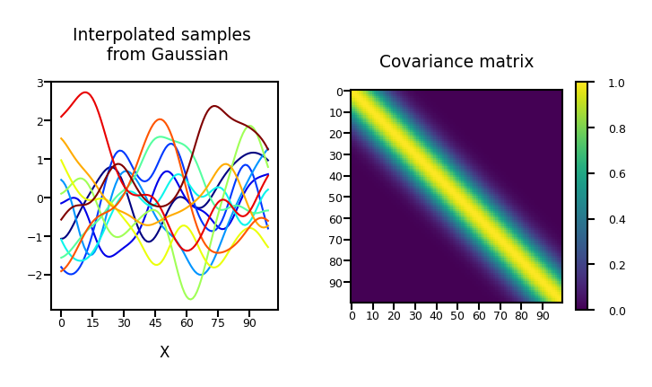

### Computing the posterior $P(\mathbf{y}|\mathbf{X})$

- Assuming that $P(X)$ is a Gaussian density with a covariance given by kernel matrix $\mathbf{K}$, the model likelihood becomes: $$ P(\mathbf{y}|\mathbf{X}) = \frac{P(y) \ P(\mathbf{X} \mid y)}{P(\mathbf{X})} = \frac{1}{(2\pi)^{\frac{n}{2}}|\mathbf{K}|^{\frac{1}{2}}} \exp\left(-\frac{1}{2}\mathbf{y}^\top \left(\mathbf{K}+\sigma^2 \mathbf{I}\right)^{-1}\mathbf{y}\right) $$
- Hence, the negative log likelihood (the objective function) is given by: $$ E(\boldsymbol{\theta}) = \frac{1}{2} \log |\mathbf{K}| + \frac{1}{2} \mathbf{y}^\top \left(\mathbf{K} + \sigma^2\mathbf{I}\right)^{-1}\mathbf{y} $$
- The model parameters (e.g. noise variance $\sigma^2$) and the kernel parameters (e.g. lengthscale, variance) can be embedded in the covariance function and learned from data.
- Good news: This loss function can be optimized using linear algebra (Cholesky Decomposition)
- Bad news: This is cubic in the number of data points AND the number of features: $\mathcal{O}(n^3 d^3)$

### Making predictions

The model makes predictions for $\mathbf{f}$ that are unaffected by future values of $\mathbf{f}^*$.  
If we think of $\mathbf{f}^*$ as test points, we can still write down a joint probability density over the training observations, $\mathbf{f}$ and the test observations, $\mathbf{f}^*$.

This joint probability density will be Gaussian, with a covariance matrix given by our kernel function, $k(\mathbf{x}_i, \mathbf{x}_j)$. $$ \begin{bmatrix}\mathbf{f} \\ \mathbf{f}^*\end{bmatrix} \sim \mathcal{N}\left(\mathbf{0}, \begin{bmatrix} \mathbf{K} & \mathbf{K}_\ast \\ \mathbf{K}_\ast^\top & \mathbf{K}_{\ast,\ast}\end{bmatrix}\right) $$

where $\mathbf{K}$ is the kernel matrix computed between all the training points,  
$\mathbf{K}_\ast$ is the kernel matrix computed between the training points and the test points,  
$\mathbf{K}_{\ast,\ast}$ is the kernel matrix computed between all the tests points and themselves.

### Conditional Density $P(\mathbf{y}|x_{test} , \mathbf{X})$

Finally, we need to define *conditional* distributions to answer particular questions of interest

We will need the *conditional density* for making predictions. $$ \mathbf{f}^* | \mathbf{y} \sim \mathcal{N}(\boldsymbol{\mu}_f,\mathbf{C}_f) $$ with a mean given by $ \boldsymbol{\mu}_f = \mathbf{K}_*^\top \left[\mathbf{K} + \sigma^2 \mathbf{I}\right]^{-1} \mathbf{y} $

and a covariance given by $ \mathbf{C}_f = \mathbf{K}_{*,*} - \mathbf{K}_*^\top \left[\mathbf{K} + \sigma^2 \mathbf{I}\right]^{-1} \mathbf{K}_\ast. $

```
interactive(children=(IntSlider(value=13, description='nr_points', max=27), Output()), _dom_classes=('widget-i…
```

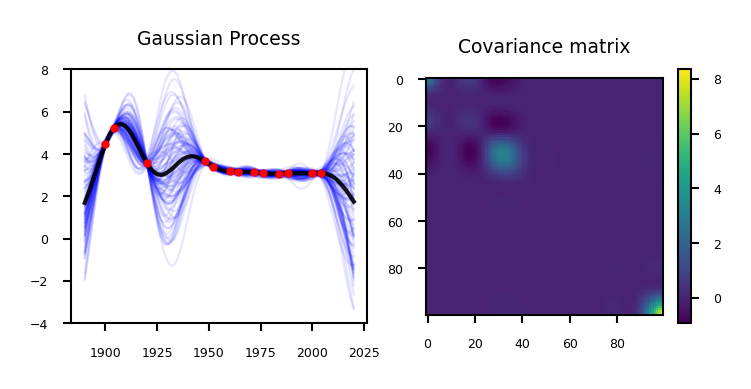

Remember that our prediction is the sum of the mean and the variance: $P(\mathbf{y}|x_{test} , \mathbf{X}) = \mathcal{N}(\mathbf{\mu,\Sigma})$

- The mean is the same as the one computed with kernel ridge (if given the same kernel and hyperparameters)
- The Gaussian process learned the covariance and the hyperparameters

```
interactive(children=(IntSlider(value=13, description='nr_points', max=27), Checkbox(value=False, description=…
```

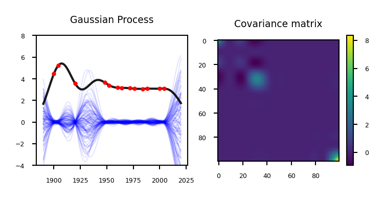

The values on the diagonal of the covariance matrix give us the variance, so we can simply plot the mean and 95% confidence interval

```
interactive(children=(IntSlider(value=13, description='nr_points', max=27), IntSlider(value=12, description='l…
```

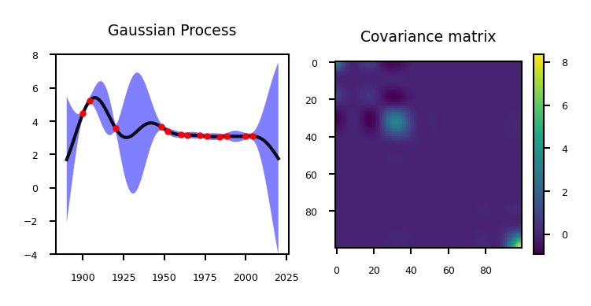

### Gaussian Processes in practice (with GPy)

- `GPyRegression`
- Generate a kernel first
  - State the dimensionality of your input data
  - Variance and lengthscale are optional, default = 1

    ```
    kernel = GPy.kern.RBF(input_dim=1, variance=1., lengthscale=1.)
    ```

  - Other kernels:

    ```
    GPy.kern.BasisFuncKernel?
    ```

- Build model:

```
m = GPy.models.GPRegression(X,Y,kernel)
```

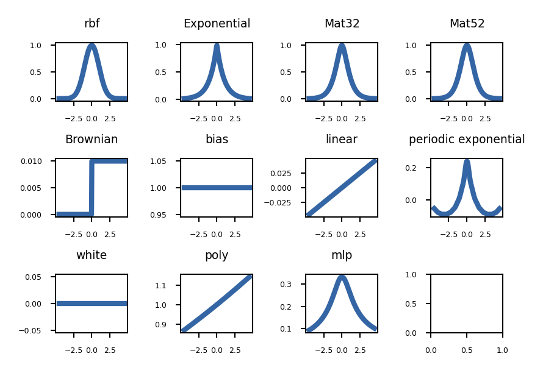

`Matern` is a generalized RBF kernel that can scale between RBF and Exponential

Build the untrained GP. The shaded region corresponds to ~95% confidence intervals (i.e. +/- 2 standard deviation)

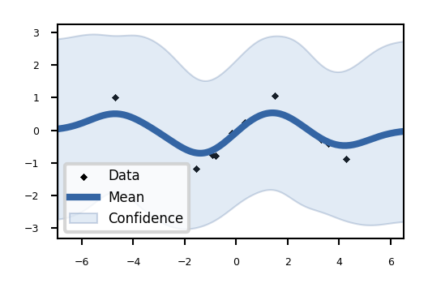

Train the model (optimize the parameters): maximize the likelihood of the data.  
Best to optimize with a few restarts: the optimizer may converges to the high-noise solution. The optimizer is then restarted with a few random initialization of the parameter values.

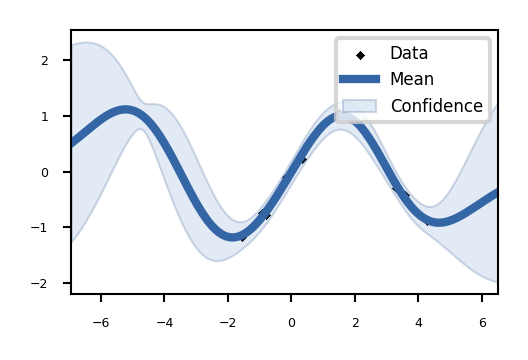

You can also show results in 2D

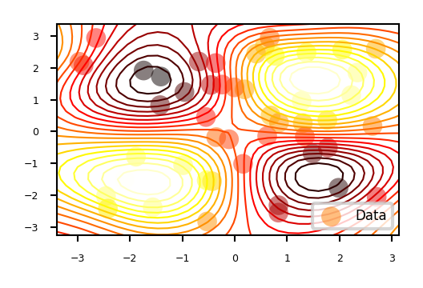

We can plot 2D slices using the `fixed_inputs` argument to the plot function.  
`fixed_inputs` is a list of tuples containing which of the inputs to fix, and to which value.

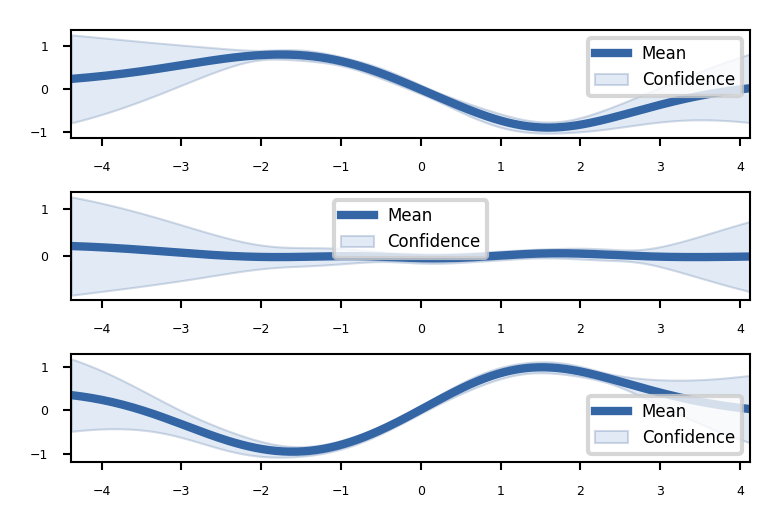

#### Gaussian Processes with scikit-learn

- `GaussianProcessRegressor`
- Hyperparameters:
  - `kernel`: kernel specifying the covariance function of the GP
    - Default: "1.0 * RBF(1.0)"
    - Typically leave at default. Will be optimized during fitting
  - `alpha`: regularization parameter
    - Tikhonov regularization of covariance between the training points.
    - Adds a (small) value to diagonal of the kernel matrix during fitting.
    - Larger values:
      - correspond to increased noise level in the observations
      - also reduce potential numerical issues during fitting
    - Default: 1e-10
  - `n_restarts_optimizer`: number of restarts of the optimizer
    - Default: 0. Best to do at least a few iterations.
    - Optimizer finds kernel parameters maximizing log-marginal likelihood
- Retrieve predictions and confidence interval after fitting:

  ```
  y_pred, sigma = gp.predict(x, return_std=True)
  ```

Example

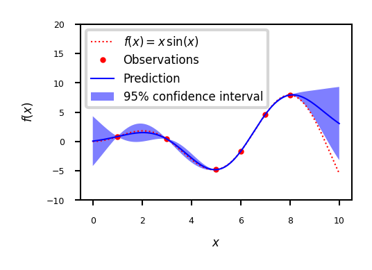

Example with noisy data

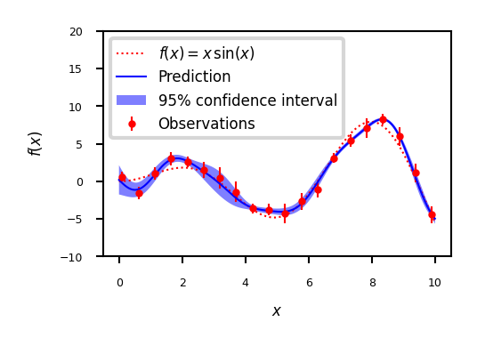

### Gaussian processes: Conclusions

Advantages:

- The prediction is probabilistic (Gaussian) so that one can compute empirical confidence intervals.
- The prediction interpolates the observations (at least for regular kernels).
- Versatile: different kernels can be specified.

Disadvantages:

- They are typically not sparse, i.e., they use the whole sample/feature information to perform the prediction.
  - Sparse GPs also exist: they remember only the most important points
- They lose efficiency in high dimensional spaces – namely when the number of features exceeds a few dozens.

### Gaussian processes and neural networks

- You can prove that a Gaussian process is equivalent to a neural network with one layer and an infinite number of nodes
- You can build *deep Gaussian Processes* by constructing layers of GPs

[figure not shown]

## Bayesian optimization

- The incremental updates you can do with Bayesian models allow a more effective way to optimize functions
  - E.g. to optimize the hyperparameter settings of a machine learning algorithm/pipeline
- After a number of random search iterations we know more about the performance of hyperparameter settings on the given dataset
- We can use this data to train a model, and predict which other hyperparameter values might be useful
  - More generally, this is called model-based optimization
  - This model is called a *surrogate model*
- This is often a probabilistic (e.g. Bayesian) model that predicts confidence intervals for all hyperparameter settings
- We use the predictions of this model to choose the next point to evaluate
- With every new evaluation, we update the surrogate model and repeat

### Example (see figure):

- Consider only 1 continuous hyperparameter (X-axis)
  - You can also do this for many more hyperparameters
- Y-axis shows cross-validation performance
- Evaluate a number of random hyperparameter settings (black dots)
  - Sometimes an initialization design is used
- Train a model, and predict the expected performance of other (unseen) hyperparameter values
  - Mean value (black line) and distribution (blue band)
- An *acquisition function* (green line) trades off maximal expected performace and maximal uncertainty
  - Exploitation vs exploration
- Optimal value of the asquisition function is the next hyperparameter setting to be evaluated
- Repeat a fixed number of times, or until time budget runs out

[figure not shown]

Shahriari et al. Taking the Human Out of the Loop: A Review of Bayesian Optimization

In 2 dimensions:

[figure not shown]

### Surrogate models

- Surrogate model can be anything as long as it can do regression and is probabilistic
- Gaussian Processes are commonly used
  - Smooth, good extrapolation, but don't scale well to many hyperparameters (cubic)
  - Sparse GPs: select ‘inducing points’ that minimize info loss, more scalable
  - Multi-task GPs: transfer surrogate models from other tasks
- Random Forests
  - A lot more scalable, but don't extrapolate well
  - Often an interpolation between predictions is used instead of the raw (step-wise) predictions
- Bayesian Neural Networks:
  - Expensive, sensitive to hyperparameters

### Acquisition Functions

- When we have trained the surrogate model, we ask it to predict a number of samples
  - Can be simply random sampling
  - Better: *Thompson sampling*
    - fit a Gaussian distribution (a mixture of Gaussians) over the sampled points
    - sample new points close to the means of the fitted Gaussians
- Typical acquisition function: *Expected Improvement*
  - Models the predicted performance as a Gaussian distribution with the predicted mean and standard deviation
  - Computes the *expected* performance improvement over the previous best configuration $\mathbf{X^+}$: $$EI(X) := \mathbb{E}\left[ \max\{0, f(\mathbf{X^+}) - f_{t+1}(\mathbf{X}) \} \right]$$
  - Computing the expected performance requires an integration over the posterior distribution, but has a [closed form solution](http://ash-aldujaili.github.io/blog/2018/02/01/ei/).

### Bayesian Optimization: conclusions

- More efficient way to optimize hyperparameters
- More similar to what humans would do
- Harder to parallellize
- Choice of surrogate model depends on your search space
  - Very active research area
  - For very high-dimensional search spaces, random forests are popular